# Prosper Loan Data Exploration

## by Kelly Wemmer

## Investigation Overview

> In the investigation, I'm interested in the correlation between different variables and how they effect the APR of the loan. The main focus is on credit score, debt to income ratio, prosper rating (Alpha), the term of loan, homeownership, and income range.

## Dataset Overview

> This dataset includes 113937 different loans and 81 variables describing credit scores, APR, employment status, among other information. After cleaning and filtering, 77557 remained to perform my analyses.

## Distribution of Borrower APR

> The Borrower APR histogram has a slightly right skewed distribution with the majority borrowers receiving an APR of around 0.22%.

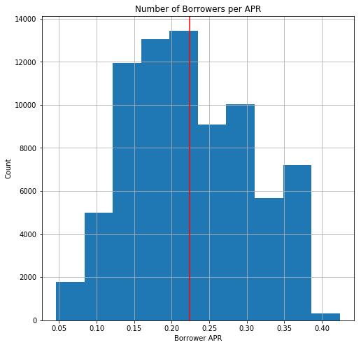

```python
#Viewing the distribution of borrower APR
apr_data['BorrowerAPR'].hist(figsize=(8,8))
plt.axvline(x=apr_data.BorrowerAPR.mean(), color = 'red')
plt.title('Number of Borrowers per APR')
plt.xlabel('Borrower APR')
plt.ylabel('Count');
```

## Average Borrower APR per Prosper Rating

> The borrowers with the higher prosper rating receive the lower APR. I would like analyze more with Prosper Rating and Debt to Income Ratio and how they both correlate to Borrower APR

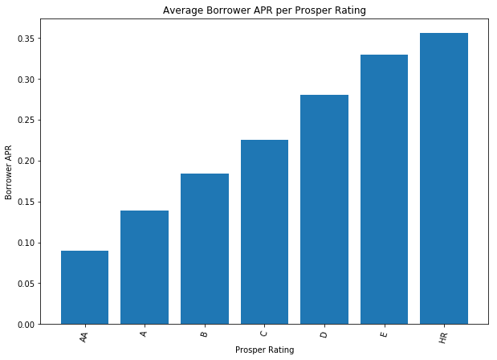

```python
plt.subplots(figsize=(10,7))
locations = [1, 2, 3, 4, 5, 6, 7]
alpha_means = [0.089999, 0.138904, 0.184074, 0.225862, 0.280037, 0.329705, 0.356216]
prosper_alpha = ["AA", "A", "B", "C", "D", "E", "HR"]
plt.xticks(rotation=75)
plt.title('Average Borrower APR per Prosper Rating')
plt.xlabel('Prosper Rating')
plt.ylabel('Borrower APR')
plt.bar(locations, alpha_means, tick_label=prosper_alpha, );
```

## Borrower APR vs Mean Credit Score

> The original plot had outliers at the zero mean credit score. These were filtered out to just analyze the credit scores between 400 and 900. There is a negative correlation between Mean Credit Score and Borrower APR. I would like to analyze Mean Credit Score with Homeownership and its correlation to APR.

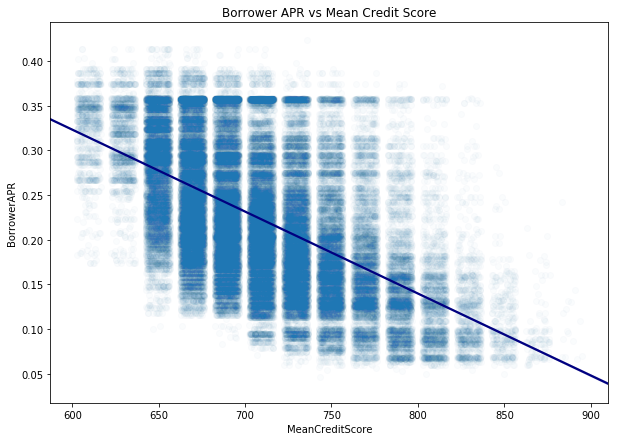

```python
#Compare BorrowerAPR with mean credit score
plt.subplots(figsize=(10,7))
credit_score = apr_data.query('MeanCreditScore >= 400')
sns.regplot(data = credit_score, x = 'MeanCreditScore', y = 'BorrowerAPR', fit_reg = True,
           x_jitter = 7, y_jitter = 0, scatter_kws={'alpha':0.02}, line_kws={'color': 'navy'})
plt.title('Borrower APR vs Mean Credit Score');
```

## Affect of Prosper Rating on Debt to Income Ratio and APR

> Borrower APR seems to increase as Prosper Rating declines.

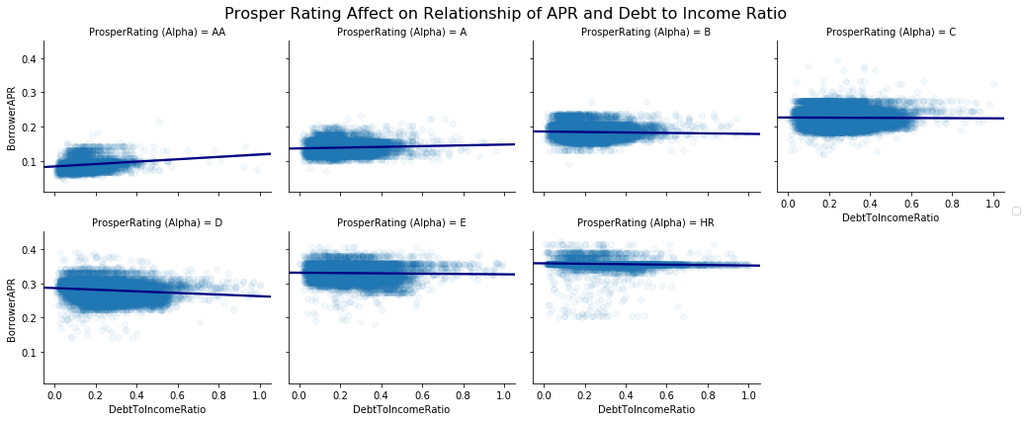

```python
# Prosper Rating effect on relationship of APR and Debt to Income Ratio
g=sns.FacetGrid(data=apr_1_less, aspect=1.2, size=3, col='ProsperRating (Alpha)', col_order=["AA", "A", "B", "C", "D", "E", "HR"], col_wrap=4)
g.map(sns.regplot, 'DebtToIncomeRatio', 'BorrowerAPR', scatter_kws={'alpha':0.05}, line_kws={'color': 'navy'})
plt.subplots_adjust(top=0.9)
g.fig.suptitle('Prosper Rating Affect on Relationship of APR and Debt to Income Ratio', fontsize=16)
g.add_legend();
```

## Affect of Income Range and Homeownership on Borrower APR

> This graph shows that higher income ranges receive the lower APR, which makes sense because higher income borrowers are seen as having less risk.

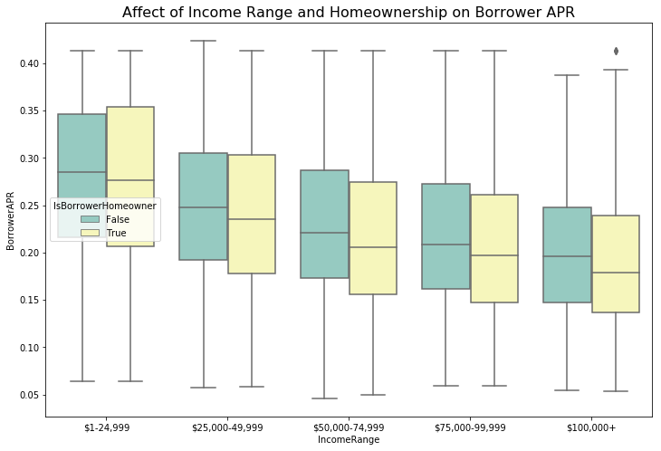

```python
# Analyzing the effect of Income Range and Homeownership to Borrower APR.
plt.figure(figsize = [12, 8])
ax = sns.boxplot(x="IncomeRange", y="BorrowerAPR", hue="IsBorrowerHomeowner", data=apr_data, order=["$1-24,999", "$25,000-49,999", "$50,000-74,999", "$75,000-99,999", "$100,000+"], palette="Set3")
plt.title('Affect of Income Range and Homeownership on Borrower APR', fontsize=16);
```

## Affect of Prosper Rating with Homownership on Mean Credit Score and APR

> The higher prosper ratings ("AA"-"B") have a negative or zero correlation between mean credit score and Borrower APR. The lower prosper ratings ("C"-"HR") tend to have a positive or zero correlation between mean credit score and Borrower APR. There must be other factors that effect these lower ratings to cause a higher APR with a higher mean credit score.

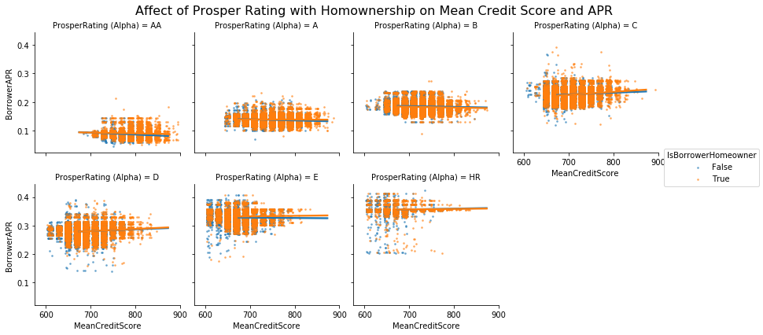

```python
#Prosper Rating with Homeownership and the correlation to mean credit score and Borrower APR
g = sns.FacetGrid(data=apr_data, col='ProsperRating (Alpha)', col_order=["AA", "A", "B", "C", "D", "E", "HR"], hue='IsBorrowerHomeowner', col_wrap=4, size=3);
g.map(sns.regplot, "MeanCreditScore", "BorrowerAPR", scatter_kws={'s': 3, 'alpha':0.5}, fit_reg=True, x_jitter=6);
plt.subplots_adjust(top=0.9)
g.set(xlim=(575, 900))
g.fig.suptitle('Affect of Prosper Rating with Homownership on Mean Credit Score and APR', fontsize=16)
g.add_legend();
```

```python
#!jupyter nbconvert slide_deck.ipynb --to slides --post serve --template output_toggle
```